# Lab 5: Insurance Costs

Author

Maile Yamasaki

Git Hub Link: https://github.com/maileyamasaki/Week_5

```python
import pandas as pd
import numpy as np
import sklearn
from sklearn.neighbors import KNeighborsRegressor
from sklearn.tree import DecisionTreeRegressor
from sklearn.linear_model import LinearRegression
from plotnine import ggplot, geom_point, aes, geom_boxplot, labs, geom_bar, geom_violin, facet_wrap, geom_smooth
import matplotlib.pyplot as plt
import seaborn as sns
from sklearn.model_selection import train_test_split
from sklearn.metrics import mean_squared_error
from sklearn.metrics import r2_score
from sklearn.preprocessing import PolynomialFeatures
```

Part 1

```python
cost = pd.read_csv("/Users/maileyamasaki/Desktop/Cal Poly SLO/Machine Learning/Week_5/insurance_costs_1.csv")
```

```python
cost.info()
cost.describe()
cost.isna().sum()
```

```
<class 'pandas.core.frame.DataFrame'>
RangeIndex: 431 entries, 0 to 430
Data columns (total 6 columns):
 #   Column   Non-Null Count  Dtype
---  ------   --------------  -----
 0   age      431 non-null    int64
 1   sex      431 non-null    object
 2   bmi      431 non-null    float64
 3   smoker   431 non-null    object
 4   region   431 non-null    object
 5   charges  431 non-null    float64
dtypes: float64(2), int64(1), object(3)
memory usage: 20.3+ KB
```

```
age        0
sex        0
bmi        0
smoker     0
region     0
charges    0
dtype: int64
```

```python
cost['female'] = 1 * (cost['sex'] == 'female')
cost['smoker'] = 1 * (cost['smoker'] == 'yes')
cost['region'] = cost['region'].astype('category')
```

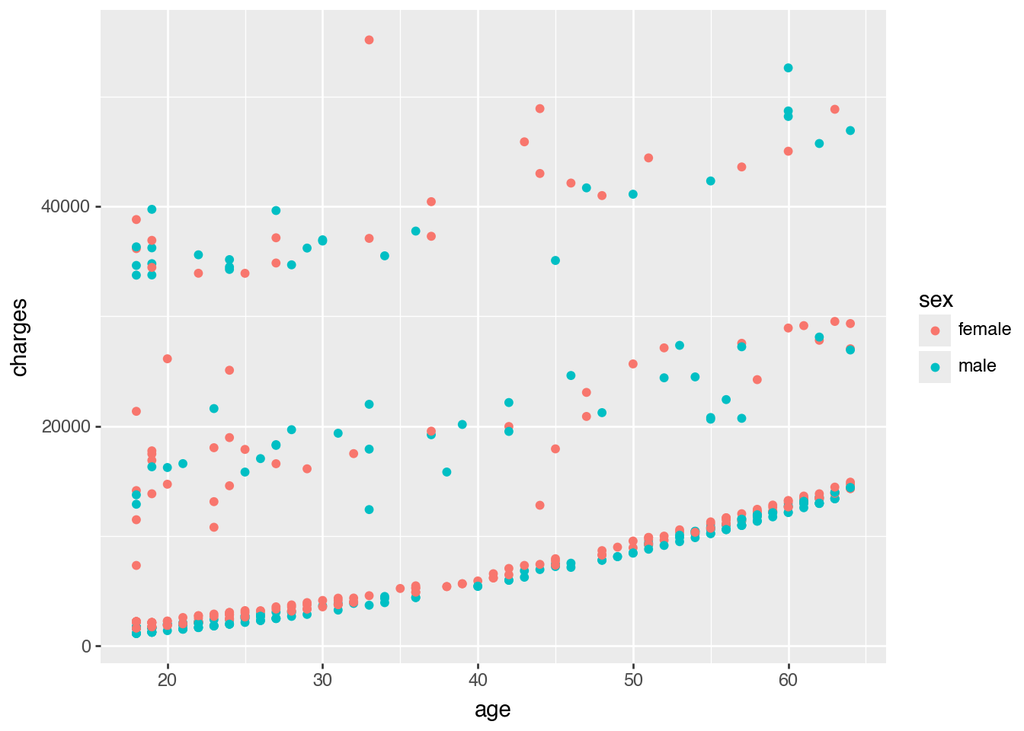

```python
(ggplot(cost, aes(x = 'age', y = 'charges', color = 'sex'))
+ geom_point()
)
```

From this plot, we can see that generally, as age increases, insurance charges tend to increase. It is difficult to tell if there is a strong difference between male and female.

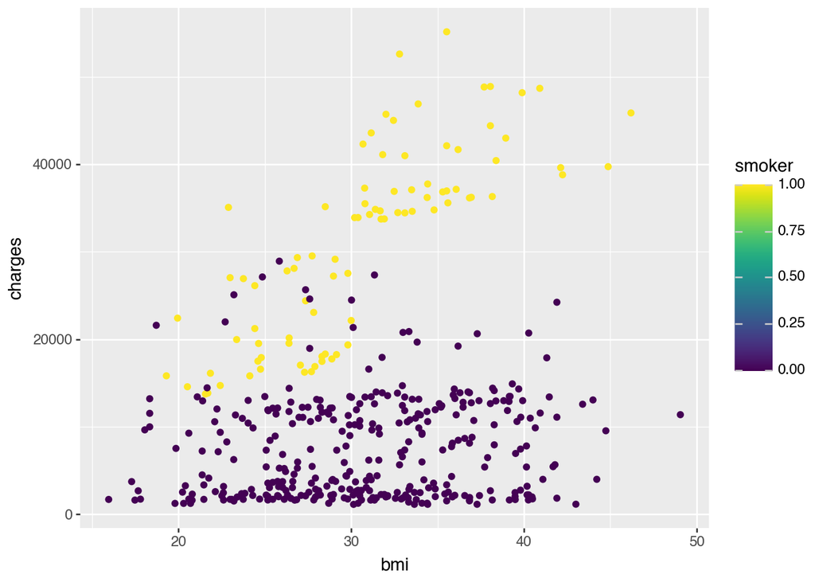

```python
(ggplot(cost, aes(x = "bmi", y = "charges", color = "smoker"))
+ geom_point()
)
```

From this plot, we can see that those who smoke tend to have higer charges. Furthermore, BMI does not have a huge effect on charges, although smokers with a high BMI see dramatically higher charges.

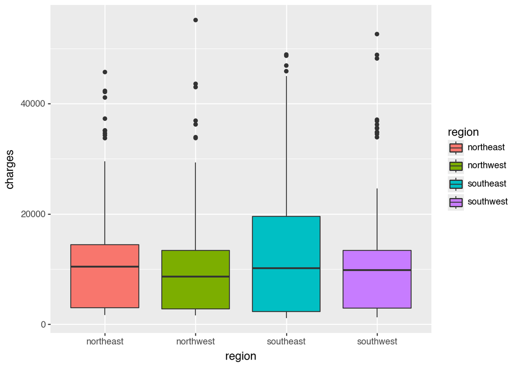

```python
(ggplot(cost, aes(x="region", y="charges", fill = 'region'))
+geom_boxplot()
)
```

From this plot, we can see that charges don’t vary greatly amongst the 4 regions, although we do see a slightly higher distribution for the southeast region.

Part 2

```python
y = cost['charges']
X1 = cost[['age']]

lr_fit1 = LinearRegression()
lr_fit1.fit(X1, y)

lr_fit1.coef_
```

```
array([228.79904937])
```

Interpretation: This model predicts that for every one-year increase in age, the average insurance charges are expected to increase by approximately $228, holding all other factors constant.

```python
y = cost['charges']
X2 = cost[['age', 'female']]

lr_fit2 = LinearRegression()
lr_fit2.fit(X2, y)

lr_fit2.coef_
```

```
array([ 228.42586236, -649.83258997])
```

Interpretation: This model predicts similar results to the first regression, seeing an approximate $228 increase in charges for every one-year increase in age, but now provides additional insight into how sex relates to insurance charges. Specifically, after controlling for age, females are predicted to have approximately $649 lower charges on average compared to males.

```python
y = cost['charges']
X3 = cost[['age', 'smoker']]

lr_fit3 = LinearRegression()
lr_fit3.fit(X3, y)

lr_fit3.coef_
```

```
array([  253.14535549, 24048.86743795])
```

Interpretation: This model predicts similar results to the first regression, seeing an approximate $253 increase in charges for every one-year increase in age, but now provides additional insight into how smoking relates to insurance charges. Specifically, after controlling for age, smokers are predicted to have approximately $24048 higher charges on average compared to non-smokers.

```python
y_pred2 = lr_fit2.predict(X2)
mse2 = mean_squared_error(y, y_pred2)
r2 = r2_score(y, y_pred2)
print('MSE for model 2 =', mse2, '\nR^2 for model 2 =', r2)
```

```
MSE for model 2 = 126633939.67937085
R^2 for model 2 = 0.10012952499706418
```

```python
y_pred3 = lr_fit3.predict(X3)
mse3 = mean_squared_error(y, y_pred3)
r3 = r2_score(y, y_pred3)
print('MSE for model 3 =', mse3, '\nR^2 for model 3 =', r3)
```

```
MSE for model 3 = 33719831.46524372
R^2 for model 3 = 0.7603842948069405
```

Our results of MSE and R^2 tell us that our third model, running the age and smoker variables is the best fit. We see a smaller MSE and higher R^2 which is our indication of a better fit. From a contextual perspective, we see that the smoker coefficient was very large, telling us that being a smoker vs. non-smoker has a big effect on insurance charges and thus provides us a better predictor of charges than the sex of a person.

Part 3

```python
y = cost['charges']
X4 = cost[['age', 'bmi']]

lr_fit4 = LinearRegression()
lr_fit4.fit(X4, y)

lr_fit4.coef_
```

```
array([216.29721472, 283.20380126])
```

```python
y_pred1 = lr_fit1.predict(X1)
mse1 = mean_squared_error(y, y_pred1)
r1 = r2_score(y, y_pred1)
print('MSE for model 1 =', mse1, '\nR^2 for model 1 =', r1)
```

```
MSE for model 1 = 126739267.9102639
R^2 for model 1 = 0.09938105452062695
```

```python
y_pred4 = lr_fit4.predict(X4)
mse4 = mean_squared_error(y, y_pred4)
r4 = r2_score(y, y_pred4)
print('MSE for model 4 =', mse4, '\nR^2 for model 4 =', r4)
```

```
MSE for model 4 = 123792439.58129103
R^2 for model 4 = 0.12032144234129338
```

Our results of MSE and R^2 tell us that our fourth model, running the age and bmi variables is the best fit. We see a smaller MSE and higher R^2 which is our indication of a better fit. From a contextual perspective, we see that the bmi factor gives us good insight as to charges - a one-percent increase in bmi leads to approximately $283 more in charges.

```python
cost['age^2'] = (cost['age'])^2

y = cost['charges']
X5 = cost[['age', 'age^2']]

lr_fit5 = LinearRegression()
lr_fit5.fit(X5, y)

lr_fit5.coef_
```

```
array([114.92554226, 111.68735444])
```

```python
y_pred5 = lr_fit5.predict(X5)
mse5 = mean_squared_error(y, y_pred5)
r5 = r2_score(y, y_pred5)
print('MSE for model 5 =', mse5, '\nR^2 for model 5 =', r5)
print('MSE for model 1 =', mse1, '\nR^2 for model 1 =', r1)
```

```
MSE for model 5 = 126691402.97000779
R^2 for model 5 = 0.09972118645234529
MSE for model 1 = 126739267.9102639
R^2 for model 1 = 0.09938105452062695
```

Our MSE and R^2 results tell us that the fifth model, running age and age^2 provides us with a better fit that when we just used age as a predictor.

```python
y = cost['charges']
X6 = cost[['age']]

poly6 = PolynomialFeatures(degree=4, include_bias=False)
X6_poly = poly6.fit_transform(X6)

lr_fit6 = LinearRegression()
lr_fit6.fit(X6_poly, y)

y_pred6 = lr_fit6.predict(X6_poly)
mse6 = mean_squared_error(y, y_pred6)
r6 = r2_score(y, y_pred6)
print('MSE for model 6 =', mse6, '\nR^2 for model 6 =', r6)
print('MSE for model 1 =', mse1, '\nR^2 for model 1 =', r1)
```

```
MSE for model 6 = 125550389.64569828
R^2 for model 6 = 0.10782931453183786
MSE for model 1 = 126739267.9102639
R^2 for model 1 = 0.09938105452062695
```

Our MSE and R^2 results tell us that the sixth model, running a fourth degree polynomial provides us with a better fit that when we just used age as a predictor.

```python
y = cost['charges']
X7 = cost[['age']]

poly7 = PolynomialFeatures(degree=12, include_bias=False)
X7_poly = poly7.fit_transform(X7)

lr_fit7 = LinearRegression()
lr_fit7.fit(X7_poly, y)

y_pred7 = lr_fit7.predict(X7_poly)
mse7 = mean_squared_error(y, y_pred7)
r7 = r2_score(y, y_pred7)
print('MSE for model 7 =', mse7, '\nR^2 for model 7 =', r7)
print('MSE for model 1 =', mse1, '\nR^2 for model 1 =', r1)
```

```
MSE for model 7 = 125618485.56892939
R^2 for model 7 = 0.10734541968548872
MSE for model 1 = 126739267.9102639
R^2 for model 1 = 0.09938105452062695
```

Our MSE and R^2 results tell us that the seventh model, running a twelfth degree polynomial provides us with a better fit that when we just used age as a predictor.

```python
print('MSE for model 1 =', mse1, '\nR^2 for model 1 =', r1)
print('MSE for model 5 =', mse5, '\nR^2 for model 5 =', r5)
print('MSE for model 6 =', mse6, '\nR^2 for model 6 =', r6)
print('MSE for model 7 =', mse7, '\nR^2 for model 7 =', r7)
```

```
MSE for model 1 = 126739267.9102639
R^2 for model 1 = 0.09938105452062695
MSE for model 5 = 126691402.97000779
R^2 for model 5 = 0.09972118645234529
MSE for model 6 = 125550389.64569828
R^2 for model 6 = 0.10782931453183786
MSE for model 7 = 125618485.56892939
R^2 for model 7 = 0.10734541968548872
```

Our MSE and R^2 results tell us that the sixth model, running a fourth degree polynomial, provides us with the best fit amongst each of the models. I agree that this is the best model, as model 1 (just age) and model 5 (age & age^2) underfit the model while model 7 (twelfth degree polynomial) overfits the model.

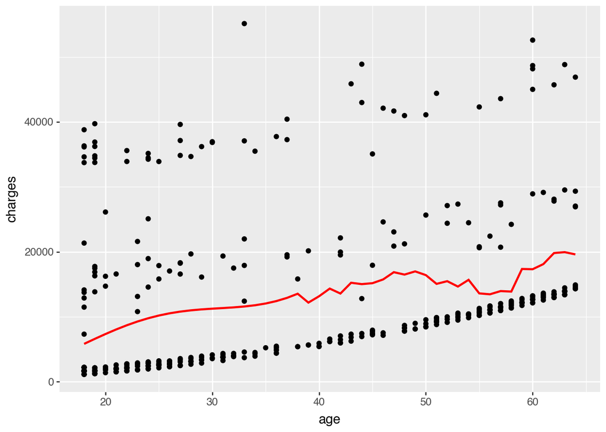

```python
(ggplot(cost, aes(x = "age", y = "charges"))
+ geom_point()
+ geom_smooth(method='lm', formula='y ~ x + I(x**2)+ I(x**3) + I(x**4) + I(x**5)+ I(x**6) + I(x**7)+ I(x**8)+ I(x**9) + I(x**10) + I(x**11)+ I(x**12)', se=False, color="red")
)
```

Part 4

```python
new_cost = pd.read_csv("/Users/maileyamasaki/Desktop/Cal Poly SLO/Machine Learning/Week_5/insurance_costs_2.csv")
```

```python
new_cost['female'] = 1 * (new_cost['sex'] == 'female')
new_cost['smoker'] = 1 * (new_cost['smoker'] == 'yes')
new_cost['region'] = new_cost['region'].astype('category')
```

Age

```python
y = cost['charges']
X8 = cost[['age']]

lr_fit8 = LinearRegression()
lr_fit8.fit(X8, y)

X8_new = new_cost[['age']]
y = new_cost['charges']

y_pred8 = lr_fit8.predict(X8_new)

mean_squared_error(y, y_pred8)
```

```
136077136.50195494
```

Age & BMI

```python
y = cost['charges']
X9 = cost[['age', 'bmi']]

lr_fit9 = LinearRegression()
lr_fit9.fit(X9, y)

X9_new = new_cost[['age', 'bmi']]
y = new_cost['charges']

y_pred9 = lr_fit9.predict(X9_new)

mean_squared_error(y, y_pred9)
```

```
132636406.11081287
```

Age, BMI, & Smoker

```python
y = cost['charges']
X10 = cost[['age', 'bmi', 'smoker']]

lr_fit10 = LinearRegression()
lr_fit10.fit(X10, y)

X10_new = new_cost[['age', 'bmi', 'smoker']]
y = new_cost['charges']

y_pred10 = lr_fit10.predict(X10_new)

mean_squared_error(y, y_pred10)
```

```
35377541.2414163
```

Age, BMI, Age*Smoker, & BMI*Smoker

```python
y = cost['charges']
X11 = cost[['age', 'bmi']].copy()
X11['age_smoker'] = cost['age'] * cost['smoker']
X11['bmi_smoker'] = cost['bmi'] * cost['smoker']

lr_fit11 = LinearRegression()
lr_fit11.fit(X11, y)

X11_new = new_cost[['age', 'bmi']].copy()
X11_new['age_smoker'] = cost['age'] * cost['smoker']
X11_new['bmi_smoker'] = cost['bmi'] * cost['smoker']
y = new_cost['charges']

y_pred11 = lr_fit11.predict(X11_new)

mean_squared_error(y, y_pred11)
```

```
258714158.20313236
```

Age, BMI, Smoker, Age*Smoker, & BMI*Smoker

```python
y = cost['charges']
X12 = cost[['age', 'bmi', 'smoker']].copy()
X12['age_smoker'] = cost['age'] * cost['smoker']
X12['bmi_smoker'] = cost['bmi'] * cost['smoker']

lr_fit12 = LinearRegression()
lr_fit12.fit(X12, y)

X12_new = new_cost[['age', 'bmi', 'smoker']].copy()
X12_new['age_smoker'] = cost['age'] * cost['smoker']
X12_new['bmi_smoker'] = cost['bmi'] * cost['smoker']

y = new_cost['charges']

y_pred12 = lr_fit12.predict(X12_new)

mean_squared_error(y, y_pred12)
```

```
761394063.2268051
```

Based on the MSE of each of these models, we see the best fit is the model using age, BMI, and smoker as our predictors.

Residual Plot

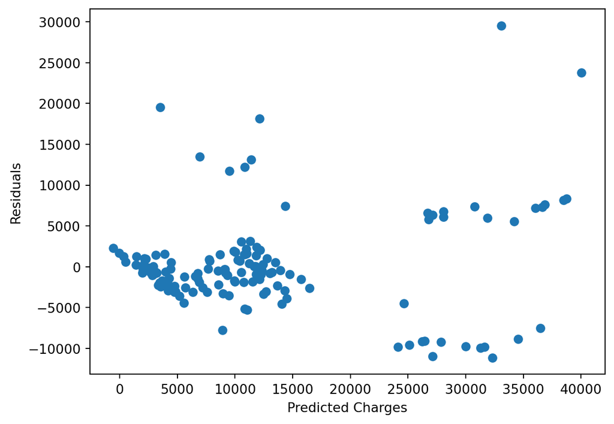

```python
residuals = y - y_pred10

plt.scatter(y_pred10, residuals)
plt.xlabel("Predicted Charges")
plt.ylabel("Residuals")
plt.show()
```

Part 5

Best Fit Model: Age, BMI, Smoker, Age*BMI

```python
y = cost['charges']
X13 = cost[['age', 'bmi', 'smoker']].copy()
X13['age_bmi'] = cost['age'] * cost['bmi']

lr_fit13 = LinearRegression()
lr_fit13.fit(X13, y)

X13_new = new_cost[['age', 'bmi', 'smoker']].copy()
X13_new['age_bmi'] = cost['age'] * cost['bmi']
y = new_cost['charges']

y_pred13 = lr_fit13.predict(X13_new)

mean_squared_error(y, y_pred13)
```

```
35167699.91516875
```

Residual Plot

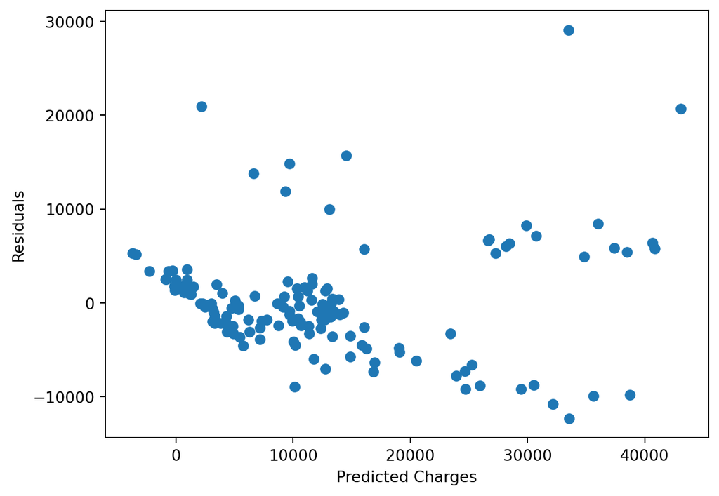

```python
residuals = y - y_pred13

plt.scatter(y_pred13, residuals)
plt.xlabel("Predicted Charges")
plt.ylabel("Residuals")
plt.show()
```